# Homework Assignment 1

Justin Applefield

Wed Nov 3, 2021

# 1 HW-1 Instructions

> Our class emphasizes clear communication of data analysis results to non-technical audiences. I expect your HTML output documents to be readable and well formatted. I expect you to put ample comments in your R code to make the code understandable. Along with accuracy of results, I am looking for quality of presentation as well. To complete this assignment, follow these steps:
1. Download the `HW1.Rmd` file from Canvas.
2. Open `HW1.Rmd` in RStudio. Replace the “Your Name Here” text in the `author:` field with your name.
3. Supply your solutions to the homework by editing `HW1.Rmd`.
4. Run your code in the Console and Knit HTML frequently to check for errors.
5. You may find it easier to solve a problem by interacting only with the Console at first.
6. When you have completed the homework please check that your knits correctly when you click `Knit HTML`.
7. “Push” all your local changes to the GitHub Repo for the project.
8. Submit your RMD file, the HTML output and a link to your GitHub Repo on Canvas.

# 2 Data frame basics

We will work with the nycflights dataset. **Please be sure to keep the data file in the same directory as the RMD file - your project directory.** and make that directory the working directory.

First - make sure that you are reading the data correctly and doing all the data cleaning steps that we did in class. Feel free to go beyond our class work in cleaning the data if you feel the need.

```r
# Read the data file
nyc <- read.csv("nycflights.csv")
nyc$X <- NULL
head(nyc)
```

```
##   year month day dep_time sched_dep_time dep_delay arr_time sched_arr_time
## 1 2013     1   1      517            515         2      830            819
## 2 2013     1   1      533            529         4      850            830
## 3 2013     1   1      542            540         2      923            850
## 4 2013     1   1      544            545        -1     1004           1022
## 5 2013     1   1      554            600        -6      812            837
## 6 2013     1   1      554            558        -4      740            728
##   arr_delay carrier flight tailnum origin dest air_time distance hour minute
## 1        11      UA   1545  N14228    EWR  IAH      227     1400    5     15
## 2        20      UA   1714  N24211    LGA  IAH      227     1416    5     29
## 3        33      AA   1141  N619AA    JFK  MIA      160     1089    5     40
## 4       -18      B6    725  N804JB    JFK  BQN      183     1576    5     45
## 5       -25      DL    461  N668DN    LGA  ATL      116      762    6      0
## 6        12      UA   1696  N39463    EWR  ORD      150      719    5     58
##             time_hour
## 1 2013-01-01 05:00:00
## 2 2013-01-01 05:00:00
## 3 2013-01-01 05:00:00
## 4 2013-01-01 05:00:00
## 5 2013-01-01 06:00:00
## 6 2013-01-01 05:00:00
```

```r
# Structure of the data
str(nyc)
```

```
## 'data.frame':    336776 obs. of  19 variables:
##  $ year          : int  2013 2013 2013 2013 2013 2013 2013 2013 2013 2013 ...
##  $ month         : int  1 1 1 1 1 1 1 1 1 1 ...
##  $ day           : int  1 1 1 1 1 1 1 1 1 1 ...
##  $ dep_time      : int  517 533 542 544 554 554 555 557 557 558 ...
##  $ sched_dep_time: int  515 529 540 545 600 558 600 600 600 600 ...
##  $ dep_delay     : int  2 4 2 -1 -6 -4 -5 -3 -3 -2 ...
##  $ arr_time      : int  830 850 923 1004 812 740 913 709 838 753 ...
##  $ sched_arr_time: int  819 830 850 1022 837 728 854 723 846 745 ...
##  $ arr_delay     : int  11 20 33 -18 -25 12 19 -14 -8 8 ...
##  $ carrier       : chr  "UA" "UA" "AA" "B6" ...
##  $ flight        : int  1545 1714 1141 725 461 1696 507 5708 79 301 ...
##  $ tailnum       : chr  "N14228" "N24211" "N619AA" "N804JB" ...
##  $ origin        : chr  "EWR" "LGA" "JFK" "JFK" ...
##  $ dest          : chr  "IAH" "IAH" "MIA" "BQN" ...
##  $ air_time      : int  227 227 160 183 116 150 158 53 140 138 ...
##  $ distance      : int  1400 1416 1089 1576 762 719 1065 229 944 733 ...
##  $ hour          : int  5 5 5 5 6 5 6 6 6 6 ...
##  $ minute        : int  15 29 40 45 0 58 0 0 0 0 ...
##  $ time_hour     : chr  "2013-01-01 05:00:00" "2013-01-01 05:00:00" "2013-01-01 05:00:00" "2013-01-01 05:00:00" ...
```

```r
# Summary of the data
summary(nyc)
```

```
##       year          month             day           dep_time    sched_dep_time
##  Min.   :2013   Min.   : 1.000   Min.   : 1.00   Min.   :   1   Min.   : 106
##  1st Qu.:2013   1st Qu.: 4.000   1st Qu.: 8.00   1st Qu.: 907   1st Qu.: 906
##  Median :2013   Median : 7.000   Median :16.00   Median :1401   Median :1359
##  Mean   :2013   Mean   : 6.549   Mean   :15.71   Mean   :1349   Mean   :1344
##  3rd Qu.:2013   3rd Qu.:10.000   3rd Qu.:23.00   3rd Qu.:1744   3rd Qu.:1729
##  Max.   :2013   Max.   :12.000   Max.   :31.00   Max.   :2400   Max.   :2359
##                                                  NA's   :8255
##    dep_delay          arr_time    sched_arr_time   arr_delay
##  Min.   : -43.00   Min.   :   1   Min.   :   1   Min.   : -86.000
##  1st Qu.:  -5.00   1st Qu.:1104   1st Qu.:1124   1st Qu.: -17.000
##  Median :  -2.00   Median :1535   Median :1556   Median :  -5.000
##  Mean   :  12.64   Mean   :1502   Mean   :1536   Mean   :   6.895
##  3rd Qu.:  11.00   3rd Qu.:1940   3rd Qu.:1945   3rd Qu.:  14.000
##  Max.   :1301.00   Max.   :2400   Max.   :2359   Max.   :1272.000
##  NA's   :8255      NA's   :8713                  NA's   :9430
##    carrier              flight       tailnum             origin
##  Length:336776      Min.   :   1   Length:336776      Length:336776
##  Class :character   1st Qu.: 553   Class :character   Class :character
##  Mode  :character   Median :1496   Mode  :character   Mode  :character
##                     Mean   :1972
##                     3rd Qu.:3465
##                     Max.   :8500
##
##      dest              air_time        distance         hour
##  Length:336776      Min.   : 20.0   Min.   :  17   Min.   : 1.00
##  Class :character   1st Qu.: 82.0   1st Qu.: 502   1st Qu.: 9.00
##  Mode  :character   Median :129.0   Median : 872   Median :13.00
##                     Mean   :150.7   Mean   :1040   Mean   :13.18
##                     3rd Qu.:192.0   3rd Qu.:1389   3rd Qu.:17.00
##                     Max.   :695.0   Max.   :4983   Max.   :23.00
##                     NA's   :9430
##      minute       time_hour
##  Min.   : 0.00   Length:336776
##  1st Qu.: 8.00   Class :character
##  Median :29.00   Mode  :character
##  Mean   :26.23
##  3rd Qu.:44.00
##  Max.   :59.00
##
```

## 2.1 Data Cleaning

We will clean our data now

```r
# Convert data to factors
nyc$flight <- as.factor(nyc$flight)
# nlevels(nyc$flight)
nyc$carrier <- as.factor(nyc$carrier)
nyc$tailnum <- as.factor(nyc$tailnum)
nyc$origin <- as.factor(nyc$origin)
nyc$dest <- as.factor(nyc$dest)

# nyc$time_hour <- as.POSIXlt(nyc$time_hour)
nyc$time_hour <- as.Date(nyc$time_hour)
# nyc$time_hour <- strptime(nyc$time_hour, "%Y-%m-%d %H:%M:%S")

str(nyc)
```

```
## 'data.frame':    336776 obs. of  19 variables:
##  $ year          : int  2013 2013 2013 2013 2013 2013 2013 2013 2013 2013 ...
##  $ month         : int  1 1 1 1 1 1 1 1 1 1 ...
##  $ day           : int  1 1 1 1 1 1 1 1 1 1 ...
##  $ dep_time      : int  517 533 542 544 554 554 555 557 557 558 ...
##  $ sched_dep_time: int  515 529 540 545 600 558 600 600 600 600 ...
##  $ dep_delay     : int  2 4 2 -1 -6 -4 -5 -3 -3 -2 ...
##  $ arr_time      : int  830 850 923 1004 812 740 913 709 838 753 ...
##  $ sched_arr_time: int  819 830 850 1022 837 728 854 723 846 745 ...
##  $ arr_delay     : int  11 20 33 -18 -25 12 19 -14 -8 8 ...
##  $ carrier       : Factor w/ 16 levels "9E","AA","AS",..: 12 12 2 4 5 12 4 6 4 2 ...
##  $ flight        : Factor w/ 3844 levels "1","2","3","4",..: 1382 1545 1042 677 425 1527 469 3700 69 266 ...
##  $ tailnum       : Factor w/ 4043 levels "D942DN","N0EGMQ",..: 180 524 2401 3204 2661 1142 1829 3300 2207 1178 ...
##  $ origin        : Factor w/ 3 levels "EWR","JFK","LGA": 1 3 2 2 3 1 1 3 2 3 ...
##  $ dest          : Factor w/ 105 levels "ABQ","ACK","ALB",..: 44 44 59 13 5 70 36 43 55 70 ...
##  $ air_time      : int  227 227 160 183 116 150 158 53 140 138 ...
##  $ distance      : int  1400 1416 1089 1576 762 719 1065 229 944 733 ...
##  $ hour          : int  5 5 5 5 6 5 6 6 6 6 ...
##  $ minute        : int  15 29 40 45 0 58 0 0 0 0 ...
##  $ time_hour     : Date, format: "2013-01-01" "2013-01-01" ...
```

```r
summary(nyc)
```

```
##       year          month             day           dep_time    sched_dep_time
##  Min.   :2013   Min.   : 1.000   Min.   : 1.00   Min.   :   1   Min.   : 106
##  1st Qu.:2013   1st Qu.: 4.000   1st Qu.: 8.00   1st Qu.: 907   1st Qu.: 906
##  Median :2013   Median : 7.000   Median :16.00   Median :1401   Median :1359
##  Mean   :2013   Mean   : 6.549   Mean   :15.71   Mean   :1349   Mean   :1344
##  3rd Qu.:2013   3rd Qu.:10.000   3rd Qu.:23.00   3rd Qu.:1744   3rd Qu.:1729
##  Max.   :2013   Max.   :12.000   Max.   :31.00   Max.   :2400   Max.   :2359
##                                                  NA's   :8255
##    dep_delay          arr_time    sched_arr_time   arr_delay
##  Min.   : -43.00   Min.   :   1   Min.   :   1   Min.   : -86.000
##  1st Qu.:  -5.00   1st Qu.:1104   1st Qu.:1124   1st Qu.: -17.000
##  Median :  -2.00   Median :1535   Median :1556   Median :  -5.000
##  Mean   :  12.64   Mean   :1502   Mean   :1536   Mean   :   6.895
##  3rd Qu.:  11.00   3rd Qu.:1940   3rd Qu.:1945   3rd Qu.:  14.000
##  Max.   :1301.00   Max.   :2400   Max.   :2359   Max.   :1272.000
##  NA's   :8255      NA's   :8713                  NA's   :9430
##     carrier          flight          tailnum       origin
##  UA     :58665   15     :   968   N725MQ :   575   EWR:120835
##  B6     :54635   27     :   898   N722MQ :   513   JFK:111279
##  EV     :54173   181    :   882   N723MQ :   507   LGA:104662
##  DL     :48110   301    :   871   N711MQ :   486
##  AA     :32729   161    :   786   N713MQ :   483
##  MQ     :26397   695    :   782   (Other):331700
##  (Other):62067   (Other):331589   NA's   :  2512
##       dest           air_time        distance         hour
##  ORD    : 17283   Min.   : 20.0   Min.   :  17   Min.   : 1.00
##  ATL    : 17215   1st Qu.: 82.0   1st Qu.: 502   1st Qu.: 9.00
##  LAX    : 16174   Median :129.0   Median : 872   Median :13.00
##  BOS    : 15508   Mean   :150.7   Mean   :1040   Mean   :13.18
##  MCO    : 14082   3rd Qu.:192.0   3rd Qu.:1389   3rd Qu.:17.00
##  CLT    : 14064   Max.   :695.0   Max.   :4983   Max.   :23.00
##  (Other):242450   NA's   :9430
##      minute        time_hour
##  Min.   : 0.00   Min.   :2013-01-01
##  1st Qu.: 8.00   1st Qu.:2013-04-04
##  Median :29.00   Median :2013-07-03
##  Mean   :26.23   Mean   :2013-07-02
##  3rd Qu.:44.00   3rd Qu.:2013-10-01
##  Max.   :59.00   Max.   :2013-12-31
##
```

I now would like you to answer the following - all in their own separate R code blocks.

## 2.2 Data Exploration

Let’s first do some simple exploration of this data.

- How many airlines are there? (Hint: `levels` and `length` can be useful here)

```r
nlevels(nyc$carrier)
```

```
## [1] 16
```

- How many flights there were by the airline with code `OO`? (Hint: `nrow` can be useful here along with logical indexing)

```r
nrow(nyc[ nyc$carrier == "OO", ])
```

```
## [1] 32
```

- How long is the shortest flight out of any NYC airport? (Hint: `min` can be useful, remember to handle `NA` values) - interpreted as shortest time.

```r
min(nyc$air_time, na.rm = TRUE)
```

```
## [1] 20
```

The shortest flight you can take out of any New York airport is 20 minutes.

- How many flights were there by United Airlines (code: UA) on Jan 12th 2013?

```r
nrow(nyc[ nyc$carrier == "UA" & nyc$time_hour == "2013-01-12", ])
```

```
## [1] 112
```

There were 112 flights by UA on Jan 12th 2013.

## 2.3 Arrival Delay

Lets focus on Arrival Delay.

- What was the average arrival delay for all airports and all airlines combined in 2013?

```r
mean(nyc$arr_delay, na.rm = TRUE)
```

```
## [1] 6.895377
```

Average arrival delay for all airports and all airlines was 6.8953768.

- Whats was the median arrival delay for all airports and all airlines combined in 2013?

```r
median(nyc$arr_delay, na.rm = TRUE)
```

```
## [1] -5
```

Median arrival delay for all airports and all airlines combined in 2013 was -5.

Based on your answers to the two questions above, what can you say about the distribution of arrival delays? Provide your answer in a text paragraph form.

Because the median arrival delay is negative and the mean arrival delay is positive, I can conclude that the majority of flights were not delayed, but there were a fair number of flights that were *very* delayed. Visually this is a distribution with a tall peak < 0, but with a long tail extending into the positives.

There are 19630 flights delayed by more than 2 hours.

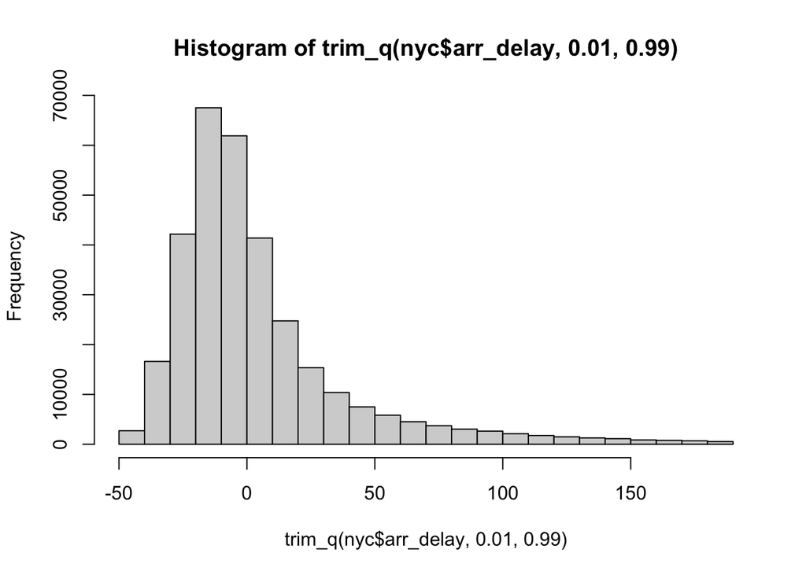

```r
trim_q <- function(x, lb, ub){
  x[(x > quantile(x, lb, na.rm=TRUE)) & (x < quantile(x, ub, na.rm=TRUE))]
}

hist(trim_q(nyc$arr_delay, 0.01, 0.99))
```

## 2.4 Airline Performance

Lets see if all airlines are equally terrible as far as flight arrival delays are concerned. For this question you will have to make sure that airline column is coded as a factor.

- Calculate average arrival delays by airline (Hint: look up the command `tapply`)

```r
arr_delay_by_airline <- sort(tapply(nyc$arr_delay, nyc$carrier, mean, na.rm = TRUE), decreasing = TRUE)
```

- Draw a Bar Plot of Average Arrival Delays for all the Airlines (Hint: command for making a Bar Plot is simply `barplot`)

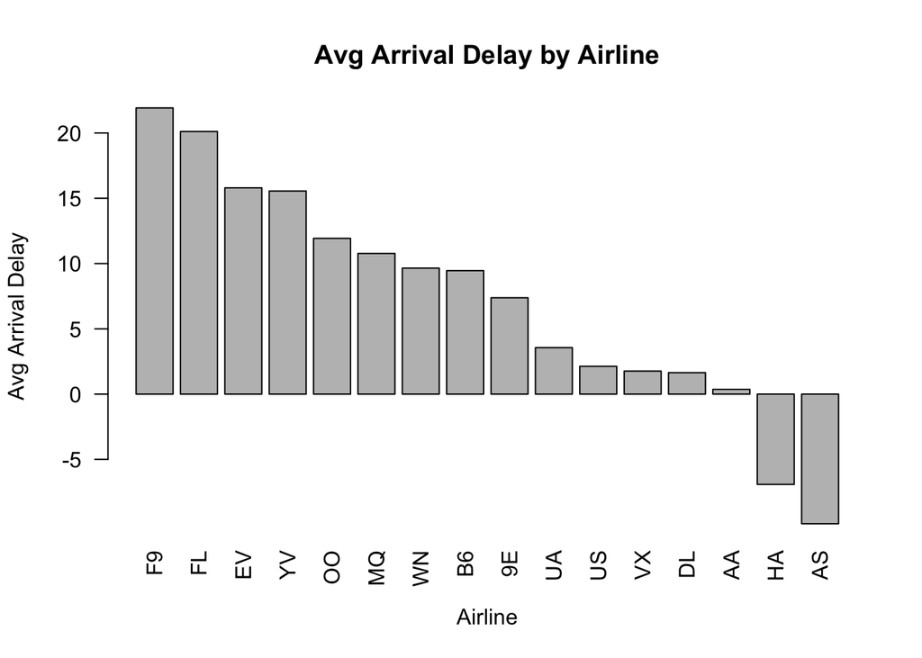

```r
barplot(arr_delay_by_airline, las=2, main="Avg Arrival Delay by Airline", xlab="Airline", ylab="Avg Arrival Delay")
```

- Which airline has the highest average arrival delay? Which airline has the smallest average arrival delay? Are there airlines that actually have negative average delay? Provide answer to this question in a text paragraph form using

The airline with the highest average arrival delay is F9. The airline with the smallest average arrival delay is AS. The airlines with negative average delay are HA, AS.

## 2.5 Air Gain

Create a new column named airgain such that airgain = (departure delay - arrival delay) : this is the amount of delay a flight made up while in air.

```r
nyc$airgain <- nyc$dep_delay - nyc$arr_delay
```

1. Explore airgain data - calculate suitable descriptive statistics and appropriate graphics to better understand this data. This part is open ended - you do what you feel works best for you.
2. Answer the questions:
- do airlines actually gain any time when in air on average?

```r
mean(nyc$airgain, na.rm = TRUE)
```

```
## [1] 5.659779
```

```r
median(nyc$airgain, na.rm = TRUE)
```

```
## [1] 7
```

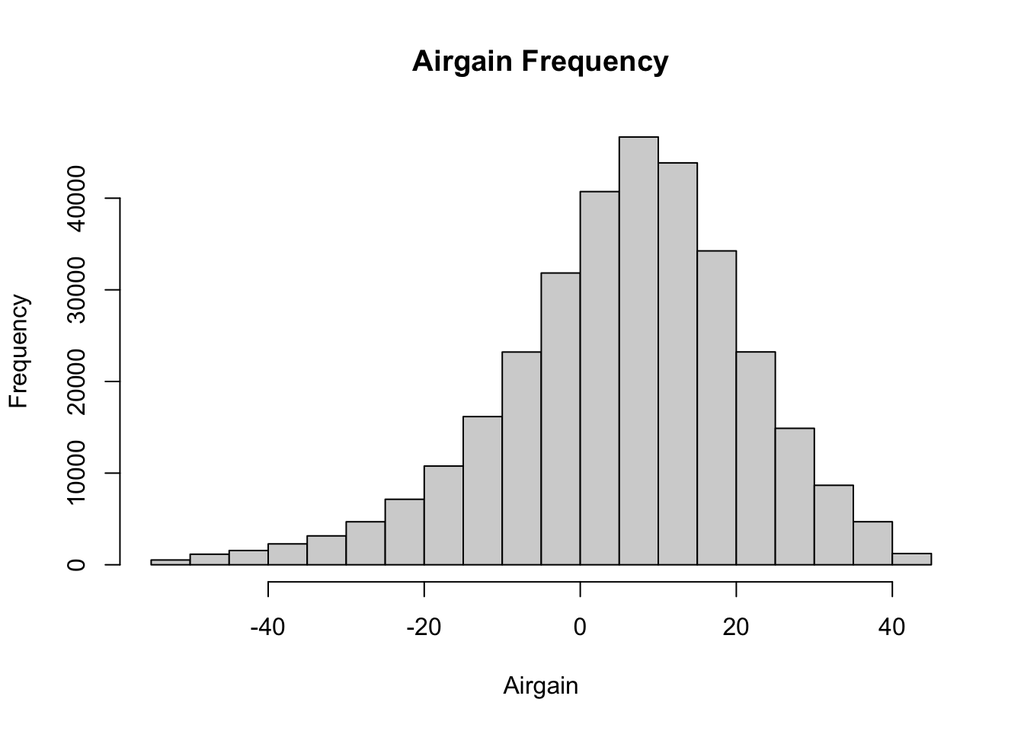

```r
hist(trim_q(nyc$airgain, 0.01, 0.99), main="Airgain Frequency", xlab="Airgain")
```

The proportion of flights with a positive (>0) airgain is 0.685901. The proportion of flights with a meaningful (>=10) airgain is 0.4543614. Airlines do on average gain some time in the air.

- Calculate average airgain for different airlines - which airlines do a better job, which do a worse job?

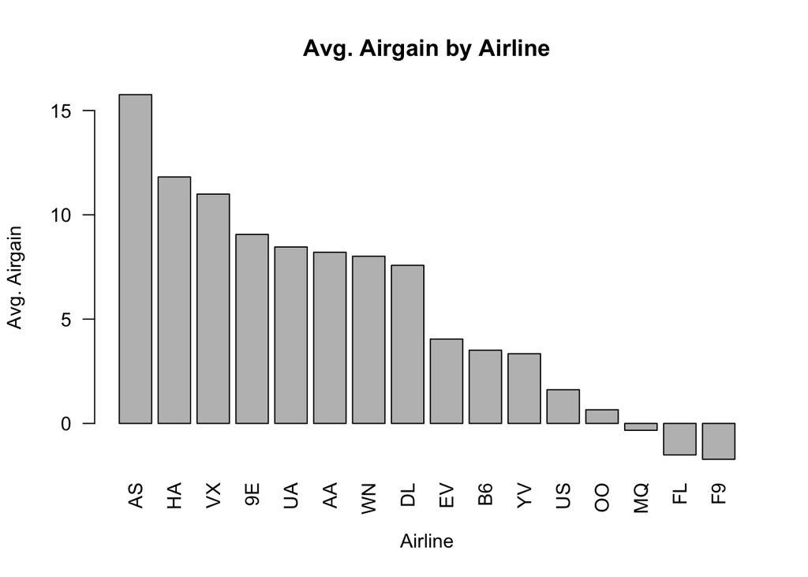

```r
avg_airgain_by_airline <- tapply(nyc$airgain, nyc$carrier, mean, na.rm = TRUE)
barplot(avg_airgain_by_airline[order(avg_airgain_by_airline, decreasing=TRUE)], las=2, main="Avg. Airgain by Airline", xlab="Airline", ylab="Avg. Airgain")
```

The best airlines by airgain are AS and HA. The worst airlines by airgain are FL and F9.

# 3 Merging Data Frames

You can get detailed information about the physical planes in our dataset in this file: `planes.csv`. Download and save this file in your project directory.

1. Read the `planes.csv` file using `read.csv` command. Do any data cleaning necessary.

```r
planes <- read.csv("planes.csv")
planes$tailnum <- as.factor(planes$tailnum)
planes$type <- as.factor(planes$type)
planes$manufacturer <- as.factor(planes$manufacturer)
planes$model <- as.factor(planes$model)
planes$engine <- as.factor(planes$engine)
planes$X <- NULL

str(planes)
```

```
## 'data.frame':    3322 obs. of  9 variables:
##  $ tailnum     : Factor w/ 3322 levels "N10156","N102UW",..: 1 2 3 4 5 6 7 8 9 10 ...
##  $ year        : int  2004 1998 1999 1999 2002 1999 1999 1999 1999 1999 ...
##  $ type        : Factor w/ 3 levels "Fixed wing multi engine",..: 1 1 1 1 1 1 1 1 1 1 ...
##  $ manufacturer: Factor w/ 35 levels "AGUSTA SPA","AIRBUS",..: 18 3 3 3 18 3 3 3 3 3 ...
##  $ model       : Factor w/ 127 levels "150","172E","172M",..: 108 87 87 87 107 87 87 87 87 87 ...
##  $ engines     : int  2 2 2 2 2 2 2 2 2 2 ...
##  $ seats       : int  55 182 182 182 55 182 182 182 182 182 ...
##  $ speed       : int  NA NA NA NA NA NA NA NA NA NA ...
##  $ engine      : Factor w/ 6 levels "4 Cycle","Reciprocating",..: 3 3 3 3 3 3 3 3 3 3 ...
```

```r
summary(planes)
```

```
##     tailnum          year                            type
##  N10156 :   1   Min.   :1956   Fixed wing multi engine :3292
##  N102UW :   1   1st Qu.:1997   Fixed wing single engine:  25
##  N103US :   1   Median :2001   Rotorcraft              :   5
##  N104UW :   1   Mean   :2000
##  N10575 :   1   3rd Qu.:2005
##  N105UW :   1   Max.   :2013
##  (Other):3316   NA's   :70
##             manufacturer          model         engines          seats
##  BOEING           :1630   737-7H4    : 361   Min.   :1.000   Min.   :  2.0
##  AIRBUS INDUSTRIE : 400   A320-232   : 256   1st Qu.:2.000   1st Qu.:140.0
##  BOMBARDIER INC   : 368   CL-600-2B19: 171   Median :2.000   Median :149.0
##  AIRBUS           : 336   CL-600-2D24: 123   Mean   :1.995   Mean   :154.3
##  EMBRAER          : 299   737-824    : 122   3rd Qu.:2.000   3rd Qu.:182.0
##  MCDONNELL DOUGLAS: 120   MD-88      : 117   Max.   :4.000   Max.   :450.0
##  (Other)          : 169   (Other)    :2172
##      speed                 engine
##  Min.   : 90.0   4 Cycle      :   2
##  1st Qu.:107.5   Reciprocating:  28
##  Median :162.0   Turbo-fan    :2750
##  Mean   :236.8   Turbo-jet    : 535
##  3rd Qu.:432.0   Turbo-prop   :   2
##  Max.   :432.0   Turbo-shaft  :   5
##  NA's   :3299
```

2. Merge the flights data and the planes data using the `merge` command. You should do the merge on the common column named `tailnum`. *getting this right may need some trial and error and getting some help*.

```r
flights_and_planes <- merge(nyc, planes, by="tailnum")
```

3. Now that you have a merged dataset, think of what interesting questions that you can ask that can be answered using the merged dataset. You are asked to pose five interesting questions and answer them. (For example: who are the top 10 manufacturers of planes that fly out of NYC airports?) **Be creative. Be bold. Ask questions that you would want to know answers to even if you were not doing this for a HW.**
- What airline has the oldest planes?

```r
airline_avg_age <- tapply(flights_and_planes$year.y, flights_and_planes$carrier, mean, na.rm = TRUE)
```

The airline with the oldest planes is MQ.

- Which plane has the best airgain?

```r
plane_avg_airgain <- tapply(flights_and_planes$airgain, flights_and_planes$model, mean, na.rm = TRUE)
```

The plane with the best airgain is the 757-212.

- Is there any difference in the most common plane of the most timely airline and the least timely airline (measured by arrival delay).

```r
Mode <- function(x) {
  ux <- unique(x)
  ux[which.max(tabulate(match(x, ux)))]
}
airline_most_common <- tapply(flights_and_planes$model, flights_and_planes$carrier, Mode)
```

The most timely airline, AS, most commonly flew a 737-890. The least timely airline, F9, most commonly flew a A320-214.

- Assuming all flights are full, which airline had the highest average delayed-passenger-minutes?

```r
flights_and_planes$del_px_mins <- flights_and_planes$seats * flights_and_planes$arr_delay
airline_avg_dpm <- tapply(flights_and_planes$del_px_mins, flights_and_planes$carrier, mean, na.rm = TRUE)
```

The airline with the highest average delayed-passenger-minutes was F9. The airline with the lowest average delayed-passenger-minutes was HA.

- Which airline flew the most passengers out of New York in 2013? The least?

```r
airline_total_px <- tapply(flights_and_planes$seats, flights_and_planes$carrier, sum, na.rm = TRUE)
```

The airline that flew the most passengers out of New York in 2013 was UA. The airline that flew the least passengers out of New York in 2013 was OO.

# 4 Making Your HTML Look Nice

We want our report to be good looking, professional documents. To that end, I am asking you to do the following:

- Have a floating table of contents
- Include code folding in your output. You can find more about code folding here: https://bookdown.org/yihui/rmarkdown/html-document.html#code-folding

That’s it. Once you are done, make sure everything works and knits well and then you can push your changes to the GitHub repo and uplaod the RMD flile and the html output to Canvas.

**Have Fun!**

Sanjeev